# Silk Road NYPD

Wajd

19 février 2018

## Silk Road NYPD

```r
library(arules)
```

```r
library(arulesViz)
```

On commence par récupérer la table sqf. Elle contient les données concernant les arrestations d’innocents

```r
dat <- read.table("sqf.csv", header=T,fill=T, encoding="utf-8", sep=";", dec=".",quote = "", na.string=" " )
dim(dat)
```

```
## [1] 45803   101
```

Pour faire une étude associative, nous devons commencer par nettoyer nos variables.

```r
#fix date and time
dat$datestop <- as.Date(sprintf("%08d", dat$datestop), format ="%m%d%Y")
dat$timestop <- as.integer(substr(sprintf("%04d", dat$timestop), 1, 2))
#clean continuous variables: age, height and weight
#age
dat$perobs[ dat$perobs<1 | dat$perobs>120 ] <- NA
head(dat$perstop)
```

```
## [1]  5  5 10  5  2  5
```

```r
dat$perstop[dat$perstop =="**"] <- NA
dat$perstop <- as.numeric(dat$perstop)
dat$dob <- NULL
```

L’âge, la taille et le poids sont des valeurs continues. Il faudra les nettoyer des valeurs aberrantes qui sont considérées ici comme des erreurs de saisie.

On commence par l’âge

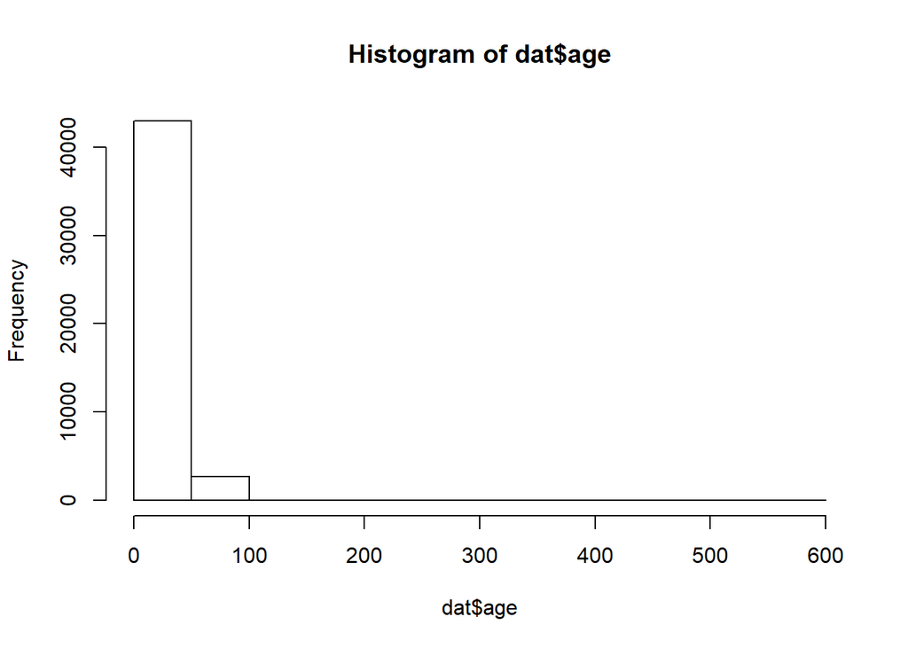

```r
hist(dat$age)
```

```r
table(dat$age)
```

```
##
##    0    1    2    3    4    5    7    8    9   10   11   12   13   14   15
##    3   55    4    2    2    4    1    2    3    7   16   61  239  606 1191
##   16   17   18   19   20   21   22   23   24   25   26   27   28   29   30
## 1736 2092 2551 2639 2755 2400 2132 2273 2082 1850 1524 1377 1237 1116 1202
##   31   32   33   34   35   36   37   38   39   40   41   42   43   44   45
##  978  931  878  879  745  710  628  604  557  511  416  448  490  490  450
##   46   47   48   49   50   51   52   53   54   55   56   57   58   59   60
##  439  405  441  417  353  364  328  325  271  224  192  163  143  123  109
##   61   62   63   64   65   66   67   68   69   70   71   72   73   74   75
##   87   84   47   42   36   35   31   13   13   17    6    9   12   11    4
##   76   77   78   79   80   83   84   85   88   89   94   95  100  107  125
##    7    1    5    5    5    1    1    2    1    2    1    1    1    1    2
##  128  146  150  160  165  170  185  206  215  220  223  225  288  366  396
##    1    1    1    4    1    3    1    1    1    1    2    1    1    1    1
##  541  565
##    1    1
```

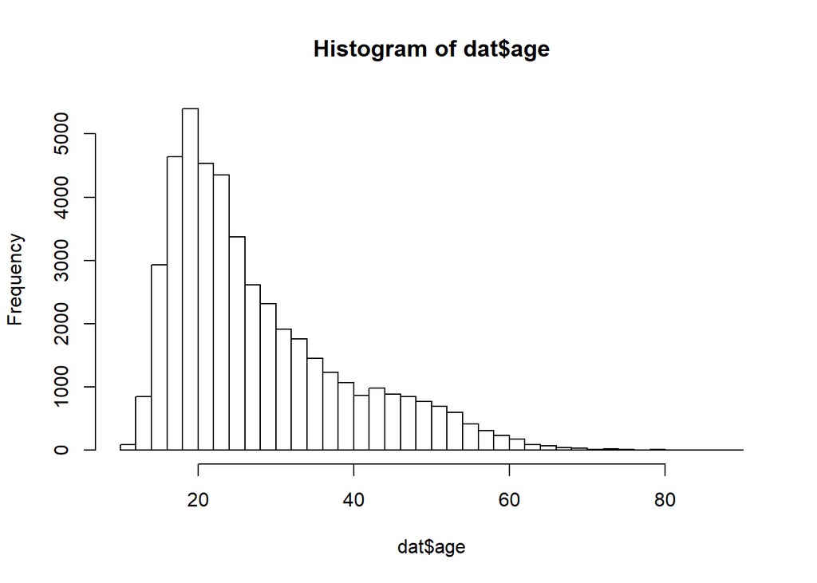

```r
dat$age[dat$age < 10 | dat$age > 90] <- NA
hist(dat$age, breaks=40)
```

On passe ensuite à la taille

```r
#height
table(dat$height)
```

```
##
##   36   40   41   42   44   45   48   49   50   51   52   53   54   55   56
##    5    1    1    2    1    1    1    2    1    2    9    5    8    6   15
##   57   58   59   60   61   62   63   64   65   66   67   68   69   70   71
##   19   13   48  338  256  565  734 1379 2564 4166 4981 5865 5731 5496 3777
##   72   73   74   75   76   77   78   79   80   81   82   83   84   95
## 4526 2266 1691  683  320  145   66   25   19    8   28   16    1    1
```

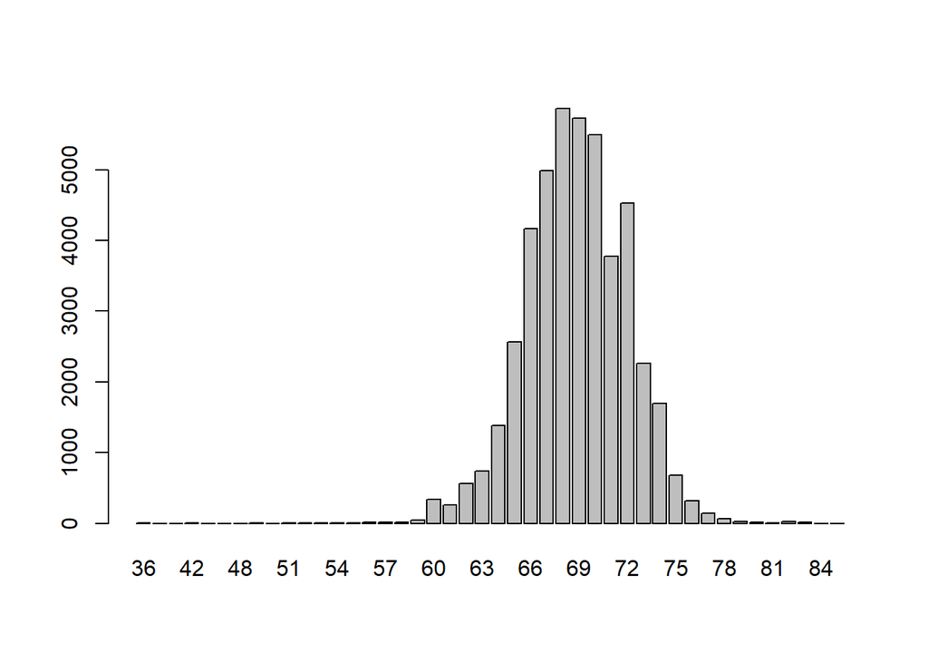

```r
barplot(table(dat$height))
```

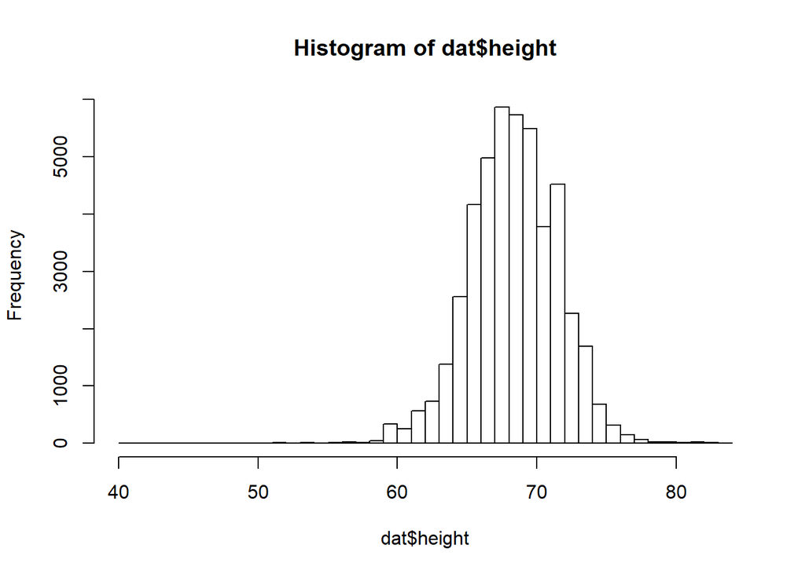

```r
dat$height[dat$height < 40 | dat$height > 90] <- NA
hist(dat$height, breaks=40)
```

Et maintenant, le poids

```r
table(dat$weight)
```

```
##
##    1    2    3    5    7    8    9   10   14   15   16   17   18   20   21
##   45    1    1    1    3    1    1    4    2    8    4    5    1    7    3
##   24   25   26   30   32   39   50   60   70   75   80   85   87   90   95
##    2    2    1    1    2    1    1    3    3    1    9    3    1   23   11
##   97   98   99  100  101  102  104  105  106  107  108  109  110  111  112
##    1    2    1  173    1    1    2   50    3    2    8    5  371    2    4
##  113  114  115  116  117  118  119  120  122  123  124  125  126  127  128
##    3    1  166    3    4    4    4  929    2    9    3  335    6    7   11
##  129  130  131  132  133  134  135  136  137  138  139  140  141  142  143
##    7 1470    3    7    6    6  484    7    6   11    7 2946    4   12    7
##  144  145  146  147  148  149  150  151  152  153  154  155  156  157  158
##    5  924   14   15   15   17 5129    4   16   11   20  883   28    9   24
##  159  160  161  162  163  164  165  166  167  168  169  170  171  172  173
##   17 6013    7   15    4    9 1801    8   11   30   14 4694    8   17    7
```

[output cut: 16 more lines]

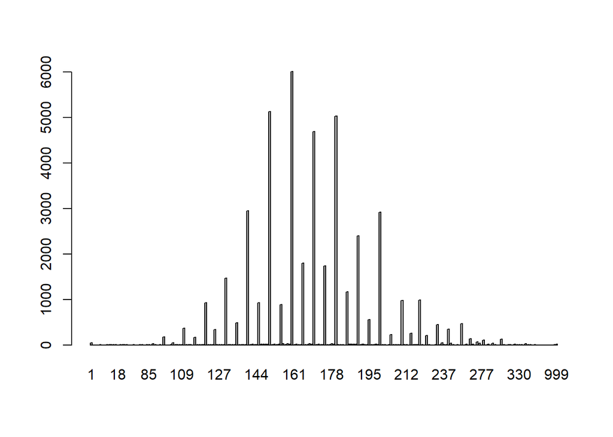

```r
barplot(table(dat$weight))
```

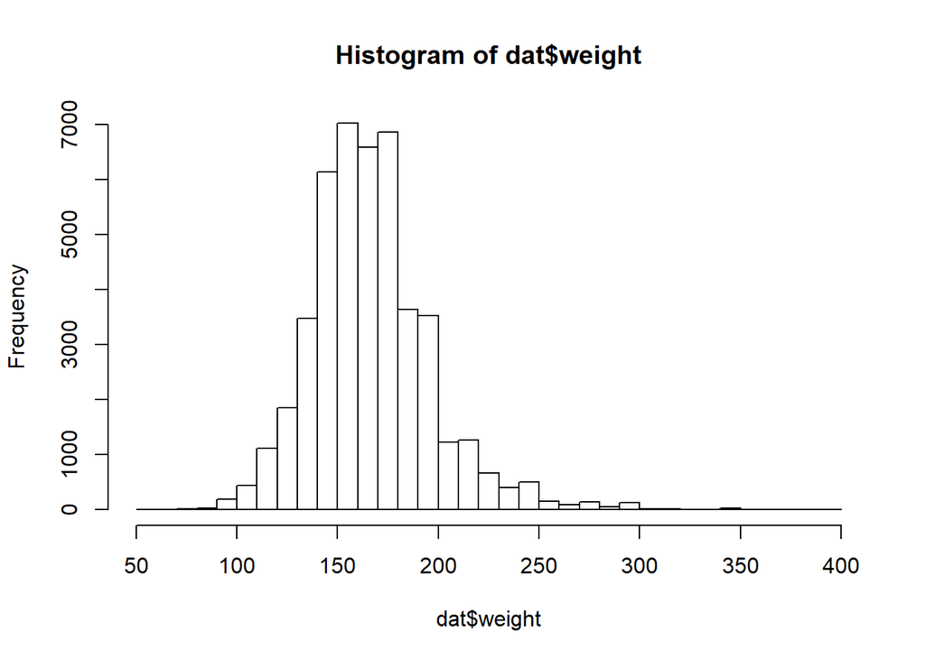

```r
dat$weight[dat$weight < 50 | dat$weight > 400] <- NA
hist(dat$weight, breaks=40)
```

On va transformer les variables nominales en factors

```r
dat$city <- factor(dat$city, labels=c("Manhattan", "Brooklyn", "Bronx",
                                      "Queens", "Staten Island"))
dat$race <- factor(dat$race, labels=c("Black", "Black Hispanic",
                                      "White Hispanic", "White", "Asian/Pacific Islander",
                                      "Am. Indian/ Native Alaskan"))
dat$sex <- factor(dat$sex+1L, label=c("female", "male"))
dat$build <- factor(dat$build, labels=c("heavy", "muscular",
                                        "medium", "thin"))
dat$forceuse[dat$forceuse==0] <- NA
dat$forceuse[is.na(dat$forceuse)] <- 7
dat$forceuse <- factor(dat$forceuse, labels =c("defense of other",
                                               "defense of self", "overcome resistence", "other",
                                               "suspected flight", "suspected weapon", "unknown"))
dat$inout[dat$inout>1] <- NA
dat$inout[is.na(dat$inout)] <- 2
dat$inout <- factor(dat$inout+1L, labels=c("outside", "inside", "unknown"))
dat$trhsloc <- factor(dat$trhsloc+1L, labels=c("neither",
                                               "housing authority", "transit authority"))
```

On a enregistré les crimes et leurs codes correspondants dans un fichier csv pour assigner à chaque code le texte du crime correspondant.

```r
crimecodes <- read.csv("crimecodes.csv",sep="\t", header = FALSE)
dat$detailcm <- factor(dat$detailcm, levels= crimecodes[,1],
                       labels=crimecodes[,2])
```

On va continuer le nettoyage en transformant les autres variables nominales en factor

```r
dat$pct <- as.factor(dat$pct)
dat$addrpct <- as.factor(dat$addrpct)
dat$sector <- as.factor(dat$sector)
dat$typeofid[dat$typeofid>3] <- 4
dat$typeofid <- factor(dat$typeofid,
                       labels=c("photo id", "verbal id", "refused to provide id", "unknown"))
dat$repcmd <- as.factor(dat$repcmd)
dat$revcmd <- as.factor(dat$revcmd)
```

On passe à présent à la transformation des variables binaires en logical

```r
binary <- strsplit("frisked searched contrabn pistol riflshot asltweap knifcuti machgun othrweap arstmade sumissue sumoffen",
                   " ")[[1]]
for(b in binary) dat[[b]] <- as.logical(dat[[b]])
#cs reason to stop
for(b in grep("cs_", colnames(dat), value=TRUE)) dat[[b]] <- as.logical(dat[[b]])
```

En sachant que rf est la raison pour la fouille, sb est la raison pour la fouille approfondie, ac est les circonstances supplémentaires de l’arrestation, et pf (les variables qui nous intéressent) décrivent la violence de l’arrestation.

```r
for(b in grep("rf_", colnames(dat), value=TRUE)) dat[[b]] <- as.logical(dat[[b]])
#sb = basis of search
for(b in grep("sb_", colnames(dat), value=TRUE)) dat[[b]] <- as.logical(dat[[b]])
#ac = additional circumstance
for(b in grep("ac_", colnames(dat), value=TRUE)) dat[[b]] <- as.logical(dat[[b]])
#pf = force used
for(b in grep("pf_", colnames(dat), value=TRUE)) dat[[b]] <- as.logical(dat[[b]])
dat$othpers <- as.logical(dat$othpers)
dat$explnstp <- as.logical(dat$explnstp)
```

offunif décrit si l’officier est en uniforme. Si l’officier est en uniforme, il n’a pas besoin de s’identifier au civil lors de l’arrestation.

```r
#If the officer is in uniform then the officer does not need to inform the person that he/she is an officer and show his/her shield.
dat$offunif <- as.logical(dat$offunif)
dat$offverb <- as.logical(dat$offverb)
dat$offverb[dat$offunif] <- NA
dat$officrid <- as.logical(dat$officrid)
dat$officrid[dat$offunif] <- NA
dat$offshld <- as.logical(dat$offshld)
dat$offshld[dat$offunif] <- NA

dat$radio <- as.logical(dat$radio)
```

On supprime les variables non utilisées

```r
#Remove unused variables
dat$year <- NULL # we only have 2014
dat$haircolr <- NULL
dat$eyecolor <- NULL
dat$ser_num <- NULL
dat$othfeatr <- NULL
dat$arstoffn <- NULL
dat$crimsusp <- NULL
dat$premname <- NULL
dat$addrnum <- NULL
dat$stname <- NULL
dat$stinter <- NULL
dat$ crossst <- NULL
dat$beat <- NULL
dat$post <- NULL
dat$recstat <- NULL
dat$linecm <- NULL
```

On enregistre les données de côté pour disposer du dataset nettoyé à l’avenir.

```r
#Check summary of cleaned data
summary(dat)
```

```
##       pct           datestop             timestop
##  106    : 2228   Min.   :2014-01-01   Min.   : 0.00
##  120    : 1934   1st Qu.:2014-03-14   1st Qu.: 8.00
##  121    : 1817   Median :2014-05-28   Median :16.00
##  105    : 1708   Mean   :2014-06-07   Mean   :13.64
##  101    : 1486   3rd Qu.:2014-08-28   3rd Qu.:20.00
##  (Other):36614   Max.   :2014-12-31   Max.   :23.00
##  NA's   :   16   NA's   :16           NA's   :16
##             city           sex                                race
##  Manhattan    : 7261   female: 2865   Black                     :24319
##  Brooklyn     :13368   male  :42528   Black Hispanic            : 2789
##  Bronx        : 6825   NA's  :  410   White Hispanic            : 9700
##  Queens       :13335                  White                     : 5467
##  Staten Island: 4998                  Asian/Pacific Islander    : 2281
##  NA's         :   16                  Am. Indian/ Native Alaskan:  192
##                                       NA's                      : 1055
##       age            height          weight           build
##  Min.   :10.00   Min.   :40.00   Min.   : 50.0   heavy   : 4070
##  1st Qu.:20.00   1st Qu.:67.00   1st Qu.:150.0   muscular:  272
##  Median :25.00   Median :69.00   Median :170.0   medium  :24462
##  Mean   :28.09   Mean   :68.84   Mean   :170.6   thin    :16262
##  3rd Qu.:34.00   3rd Qu.:71.00   3rd Qu.:185.0   NA's    :  737
##  Max.   :89.00   Max.   :84.00   Max.   :400.0
##  NA's   :228     NA's   :22      NA's   :143
##  frisked         searched        contrabn         pistol
##  Mode:logical   Mode :logical   Mode :logical   Mode :logical
##  NA's:45803     FALSE:38504     FALSE:43971     FALSE:34783
##                 TRUE :7282      TRUE :1815      TRUE :197
##                 NA's :17        NA's :17        NA's :10823
##
##
##
##   riflshot        asltweap        knifcuti        machgun
##  Mode :logical   Mode :logical   Mode :logical   Mode :logical
##  FALSE:34925     FALSE:34924     FALSE:34113     FALSE:34926
##  TRUE :2         TRUE :3         TRUE :1068      NA's :10877
##  NA's :10876     NA's :10876     NA's :10622
##
##
##
```

[output cut: 129 more lines]

```
##  Mode :logical   Mode :logical   Mode :logical   Mode :logical
##  FALSE:20966     FALSE:6401      FALSE:20079     FALSE:205
##  TRUE :24792     TRUE :14565     TRUE :887       TRUE :20761
##  NA's :45        NA's :24837     NA's :24837     NA's :24837
##
##
##
##    radio
##  Mode :logical
##  FALSE:30517
##  TRUE :15241
##  NA's :45
##
##
##
```

```r
save(dat, file="SFQ_clean.rda")
```

Ce serait intéressant de visualiser les proportions d’arrestations par rapport à la population totale

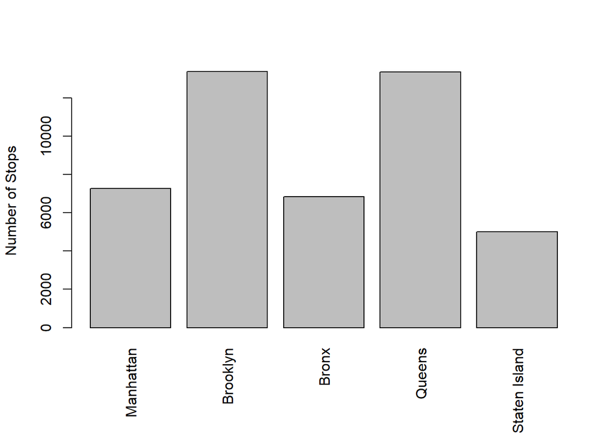

```r
oldpar <- par("mar" = c(6,4,4,2)+.1)
barplot(table(dat$city), ylab="Number of Stops", las=3)
```

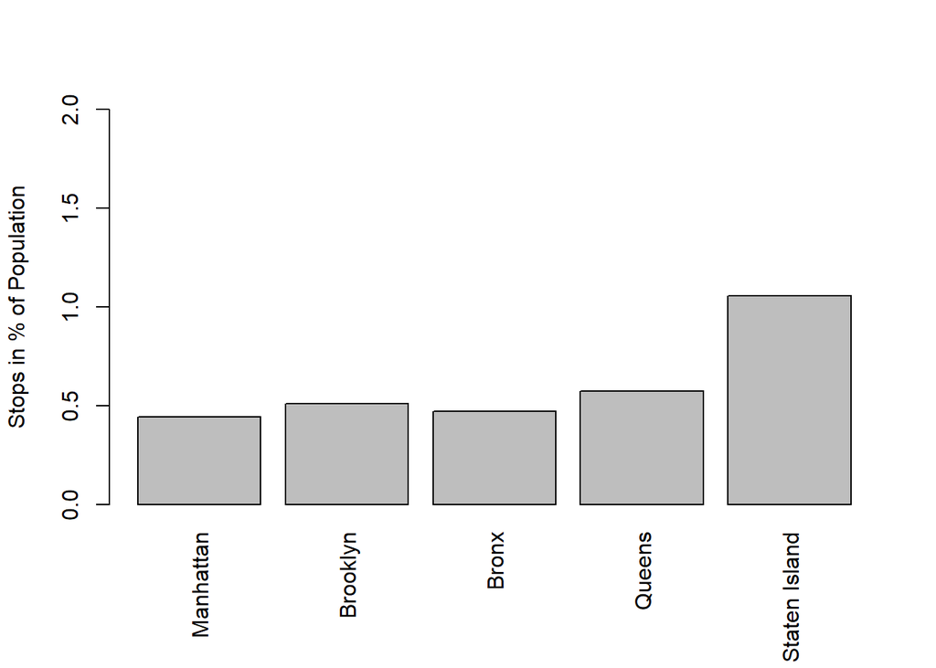

```r
par(oldpar)
#2014 stats
#manhattan 1637000 persons
#Brooklyn 2621000 persons
#bronx 1442000 perons
#queens 2322000 persons
#staten island 473301 persons

pop <- c(Manhattan =1637000, Brooklyn = 2621000, Bronx = 1442000,
         Queens =2322000, 'Staten Island'=473301)
oldpar <- par("mar" = c(6,4,4,2)+.1)
barplot(table(dat$city)/pop*100, ylab="Stops in % of Population",
        las=3, ylim=c(0,2))
```

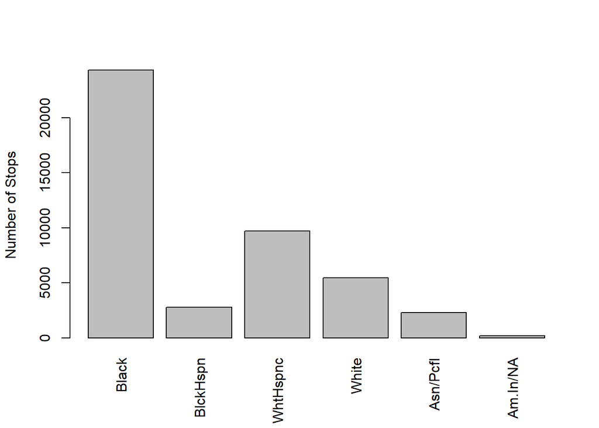

```r
tbl <- table(dat$race)
names(tbl) <- abbreviate(names(tbl), 8)
barplot(tbl, ylab="Number of Stops", las=3)
```

On compare par ailleurs les proportions d’arrestations par race par rapport aux proportions des races par rapport à la population totale.

```r
#compare to population
pop <- c(White=44.6, Black=25.1, Hispanic=27.5, Other=11.8)
sum(pop)
```

```
## [1] 109
```

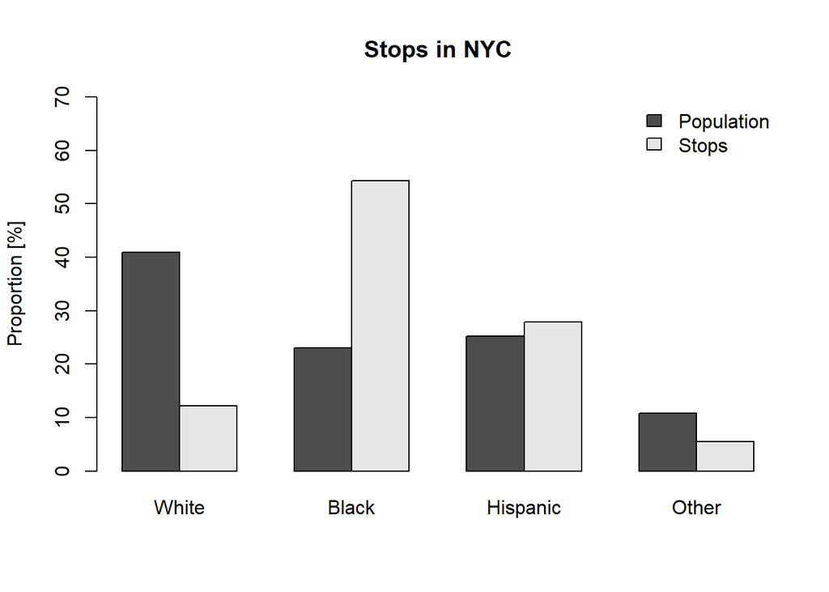

```r
#does not add up to 100
#aggregate data so the groups match the population data
pop <- pop/sum(pop)
#race proportion vs stops proportion

tbl <- table(dat$race)
tbl <- c(tbl["White"], tbl["Black"],
         tbl["White Hispanic"]+tbl["Black Hispanic"],
         tbl["Asian/Pacific Islander"]+tbl["Am. Indian/ Native Alaskan"])
names(tbl) <- c("White", "Black", "Hispanic", "Other")
tbl <- tbl/sum(tbl)

barplot((rbind(pop, tbl)*100), beside = TRUE, ylab="Proportion [%]",
        col=gray.colors(2), ylim=c(0,70), main = "Stops in NYC")
legend(x = "topright", legend = c("Population", "Stops"),
       fill=gray.colors(2), bty="n")
```

On va sélectionner à présent la race

```r
#Choose only a subset of variables

d_violence <- dat[, c(
  #pf = force used
#  grep("pf_", colnames(dat), value = TRUE),
  #crime code desc
  #race
  #precinct knife contraband other weapon
  "race"
  ,#,"detailcm",
  "city" ### city and precinct are related
  #were other persons arrested
)]
```

Puis le sexe, l’âge, puis grouper les différentes modalités de la violence.

Si le suspect a été violenté avec les mains, plaqué contre le sol ou contre un mur, on considèrera qu’il a subi de la manual violence

Si le suspect a reçu des coups de bâton, a été menotté ou a reçu du pepper spray dans la figure, on considèrera qu’il a subi de la tool violence

Enfin, si le suspect a été menacé avec une arme à feu, on considèrera qu’il a subit de la gun violence.

```r
d_violence$isfemale <- dat$sex == "female"
d_violence=d_violence[,!(names(d_violence) %in% c("city"))]
d_violence$ismale <- dat$sex == "male"
d_violence$isminor <- dat$age<18
d_violence$ismajor <- dat$age>17
d_violence$manual_violence <- dat$pf_hands | dat$pf_wall | dat$pf_grnd
d_violence$tool_violence <- dat$pf_hcuff | dat$pf_baton | dat$pf_pepsp
d_violence$gun_violence <- dat$pf_drwep | dat$pf_ptwep
d_violence$other_violence <- dat$pf_other
```

On peut à présent passer à l’usage de l’algorithme apriori pour les associations. Il sera intéressant d’isoler les différentes “races” dans notre analyse, pour étudier le comportement de la police américaine selon les “races” des personnes qu’elle arrête.

```r
trans_violence <- as(d_violence, "transactions")
summary(trans_violence)
```

```
## transactions as itemMatrix in sparse format with
##  45803 rows (elements/itemsets/transactions) and
##  14 columns (items) and a density of 0.2330306
##
## most frequent items:
##              ismale             ismajor          race=Black
##               42528               39627               24319
## race=White Hispanic     manual_violence             (Other)
##                9700                8252               25003
##
## element (itemset/transaction) length distribution:
## sizes
##     0     1     2     3     4     5     6     7
##    23   207   840 33457  9400  1690   181     5
##
##    Min. 1st Qu.  Median    Mean 3rd Qu.    Max.
##   0.000   3.000   3.000   3.262   3.000   7.000
##
## includes extended item information - examples:
##                labels variables         levels
## 1          race=Black      race          Black
## 2 race=Black Hispanic      race Black Hispanic
## 3 race=White Hispanic      race White Hispanic
##
## includes extended transaction information - examples:
##   transactionID
## 1             1
## 2             2
## 3             3
```

```r
itemLabels(trans_violence)
```

```
##  [1] "race=Black"                      "race=Black Hispanic"
##  [3] "race=White Hispanic"             "race=White"
##  [5] "race=Asian/Pacific Islander"     "race=Am. Indian/ Native Alaskan"
##  [7] "isfemale"                        "ismale"
##  [9] "isminor"                         "ismajor"
## [11] "manual_violence"                 "tool_violence"
## [13] "gun_violence"                    "other_violence"
```

```r
r_violence <- apriori(d_violence, parameter = list(sup=0.001,conf=0.5,target="rules", maxlen=4, minlen=2))
```

```
## Apriori
##
## Parameter specification:
##  confidence minval smax arem  aval originalSupport maxtime support minlen
##         0.5    0.1    1 none FALSE            TRUE       5   0.001      2
##  maxlen target   ext
##       4  rules FALSE
##
## Algorithmic control:
##  filter tree heap memopt load sort verbose
##     0.1 TRUE TRUE  FALSE TRUE    2    TRUE
##
## Absolute minimum support count: 45
##
## set item appearances ...[0 item(s)] done [0.00s].
## set transactions ...[14 item(s), 45803 transaction(s)] done [0.01s].
## sorting and recoding items ... [14 item(s)] done [0.00s].
## creating transaction tree ... done [0.01s].
## checking subsets of size 1 2 3 4 done [0.00s].
## writing ... [222 rule(s)] done [0.00s].
## creating S4 object  ... done [0.00s].
```

```r
w= subset( r_violence, subset = ( (lhs %pin% "race=Black" )  | ( rhs %pin% "race=Black" ) ))
w=as(w,"data.frame")
w=w[order(w$lift, decreasing=T),]
wruleslife= data.frame(w$rules, w$lift)
head(wruleslife,25)
```

```
##                                                         w.rules   w.lift
## 1  {race=Black,tool_violence,gun_violence} => {manual_violence} 4.249627
## 2         {race=Black,ismale,gun_violence} => {manual_violence} 3.426696
## 3                {race=Black,gun_violence} => {manual_violence} 3.391055
## 4        {race=Black,ismajor,gun_violence} => {manual_violence} 3.253060
## 5                 {ismale,isminor,gun_violence} => {race=Black} 1.255616
## 6                        {isminor,gun_violence} => {race=Black} 1.248052
## 7                {ismale,isminor,tool_violence} => {race=Black} 1.200981
## 8                       {isminor,tool_violence} => {race=Black} 1.187078
## 9                              {ismale,isminor} => {race=Black} 1.176451
## 10      {isminor,manual_violence,tool_violence} => {race=Black} 1.163292
## 11                                    {isminor} => {race=Black} 1.153550
## 12             {ismale,isminor,manual_violence} => {race=Black} 1.150982
## 13                    {isminor,manual_violence} => {race=Black} 1.132741
## 14                     {isfemale,tool_violence} => {race=Black} 1.065894
## 15             {isfemale,ismajor,tool_violence} => {race=Black} 1.065861
## 16    {race=Black Hispanic,isminor,manual_violence} => {ismale} 1.056494
## 17 {manual_violence,tool_violence,gun_violence} => {race=Black} 1.054718
## 18          {ismale,tool_violence,gun_violence} => {race=Black} 1.053006
## 19            {race=Black Hispanic,manual_violence} => {ismale} 1.049034
## 20    {race=Black Hispanic,ismajor,manual_violence} => {ismale} 1.047652
## 21        {ismale,manual_violence,gun_violence} => {race=Black} 1.042125
## 22                      {race=Black,other_violence} => {ismale} 1.039350
## 23             {race=Black,ismajor,manual_violence} => {ismale} 1.037828
## 24               {manual_violence,gun_violence} => {race=Black} 1.037173
## 25                     {race=Black,manual_violence} => {ismale} 1.036418
```

Les noirs sont associés à tous les types de violence fortement. La majorité des noirs de cette catégorie sont des mâles majeurs, mais une autre catégorie souffre exactement des mêmes type de violence et constitue des mâles mineurs.

Même les femmes noires ne sont pas épargnées. Elles sont généralement majeures et souffrent de violences avec des outils.

Quand il s’agit des hispaniques noirs, ils sont majoritairement des mâles et souffrent de violence manuelle lors de l’arrestation. Ils sont tant majeurs que mineurs à être associés à la violence.

```r
r_violence <- apriori(d_violence, parameter = list(sup=0.001,conf=0.5,target="rules", maxlen=4, minlen=2))
```

```
## Apriori
##
## Parameter specification:
##  confidence minval smax arem  aval originalSupport maxtime support minlen
##         0.5    0.1    1 none FALSE            TRUE       5   0.001      2
##  maxlen target   ext
##       4  rules FALSE
##
## Algorithmic control:
##  filter tree heap memopt load sort verbose
##     0.1 TRUE TRUE  FALSE TRUE    2    TRUE
##
## Absolute minimum support count: 45
##
## set item appearances ...[0 item(s)] done [0.00s].
## set transactions ...[14 item(s), 45803 transaction(s)] done [0.01s].
## sorting and recoding items ... [14 item(s)] done [0.00s].
## creating transaction tree ... done [0.01s].
## checking subsets of size 1 2 3 4 done [0.00s].
## writing ... [222 rule(s)] done [0.00s].
## creating S4 object  ... done [0.00s].
```

```r
w= subset( r_violence, subset = ( (lhs %pin% "race=White" )  | ( rhs %pin% "race=White" ) ))
w=as(w,"data.frame")
w=w[order(w$lift, decreasing=T),]
wruleslife= data.frame(w$rules, w$lift)
head(wruleslife,25)
```

```
##                                                            w.rules
## 1   {race=White Hispanic,ismale,gun_violence} => {manual_violence}
## 2  {race=White Hispanic,ismajor,gun_violence} => {manual_violence}
## 3          {race=White Hispanic,gun_violence} => {manual_violence}
## 4                          {race=White,tool_violence} => {ismajor}
## 5           {race=White Hispanic,ismale,gun_violence} => {ismajor}
## 6  {race=White Hispanic,manual_violence,gun_violence} => {ismajor}
## 7                   {race=White,ismale,tool_violence} => {ismajor}
## 8                  {race=White Hispanic,gun_violence} => {ismajor}
## 9                                 {race=White,ismale} => {ismajor}
## 10                                       {race=White} => {ismajor}
## 11                              {race=White,isfemale} => {ismajor}
## 12                {race=White Hispanic,other_violence} => {ismale}
## 13                       {race=White,manual_violence} => {ismajor}
## 14                {race=White,ismale,manual_violence} => {ismajor}
```

[output cut: 37 more lines]

Les Hispaniques blancs sont associés fortement à de la violence avec des armes blanches et des armes à feu, ainsi qu’à la main. La plupart sont des mâles et ont plus de 18 ans. De plus, une catégorie de blancs mâles et majeurs est associée à de la violence manuelle ou avec des armes blanches. Une autre catégorie est mineure et est associée à de la violence manuelle. Enfin, une dernière catégorie est une catégorie de femmes majeures qui souffrent de violence manuelle.

```r
r_violence <- apriori(d_violence, parameter = list(sup=0.0001,conf=0.5,target="rules", maxlen=4, minlen=2))
```

```
## Apriori
##
## Parameter specification:
##  confidence minval smax arem  aval originalSupport maxtime support minlen
##         0.5    0.1    1 none FALSE            TRUE       5   1e-04      2
##  maxlen target   ext
##       4  rules FALSE
##
## Algorithmic control:
##  filter tree heap memopt load sort verbose
##     0.1 TRUE TRUE  FALSE TRUE    2    TRUE
##
## Absolute minimum support count: 4
##
## set item appearances ...[0 item(s)] done [0.00s].
## set transactions ...[14 item(s), 45803 transaction(s)] done [0.01s].
## sorting and recoding items ... [14 item(s)] done [0.00s].
## creating transaction tree ... done [0.01s].
## checking subsets of size 1 2 3 4 done [0.00s].
## writing ... [371 rule(s)] done [0.00s].
## creating S4 object  ... done [0.00s].
```

```r
w= subset( r_violence, subset = ( (lhs %pin% "race=Am" )  | ( rhs %pin% "race=Am" ) ))
w=as(w,"data.frame")
w=w[order(w$lift, decreasing=T),]
wruleslife= data.frame(w$rules, w$lift)
head(wruleslife,25)
```

```
##                                                                        w.rules
## 1                  {race=Am. Indian/ Native Alaskan,tool_violence} => {ismale}
## 2  {race=Am. Indian/ Native Alaskan,manual_violence,tool_violence} => {ismale}
## 3          {race=Am. Indian/ Native Alaskan,ismajor,tool_violence} => {ismale}
## 4                        {race=Am. Indian/ Native Alaskan,isminor} => {ismale}
## 5                                {race=Am. Indian/ Native Alaskan} => {ismale}
## 6                        {race=Am. Indian/ Native Alaskan,ismajor} => {ismale}
## 7                      {race=Am. Indian/ Native Alaskan,isfemale} => {ismajor}
## 8                               {race=Am. Indian/ Native Alaskan} => {ismajor}
## 9                        {race=Am. Indian/ Native Alaskan,ismale} => {ismajor}
## 10                {race=Am. Indian/ Native Alaskan,tool_violence} => {ismajor}
## 11         {race=Am. Indian/ Native Alaskan,ismale,tool_violence} => {ismajor}
## 12       {race=Am. Indian/ Native Alaskan,ismajor,manual_violence} => {ismale}
## 13               {race=Am. Indian/ Native Alaskan,manual_violence} => {ismale}
## 14       {race=Am. Indian/ Native Alaskan,ismale,manual_violence} => {ismajor}
```

[output cut: 17 more lines]